# 03_Deer_Exploratory_Analysis.Rmd

Ruixin Yang

2026-10-29

```r
# Count deer observations by year
annual_counts <- as.data.frame(
  table(df_deer_clean$year)
)

# Rename columns
names(annual_counts) <- c("Year", "Observations")

# Convert year and count to numeric
annual_counts$Year <- as.integer(
  as.character(annual_counts$Year)
)

annual_counts$Observations <- as.integer(
  annual_counts$Observations
)

# View the summary table
annual_counts
```

```
##    Year Observations
## 1  2010           12
## 2  2011           15
## 3  2012           19
## 4  2013           40
## 5  2014           47
## 6  2015           77
## 7  2016          150
## 8  2017          291
## 9  2018          452
## 10 2019          740
## 11 2020         1048
```

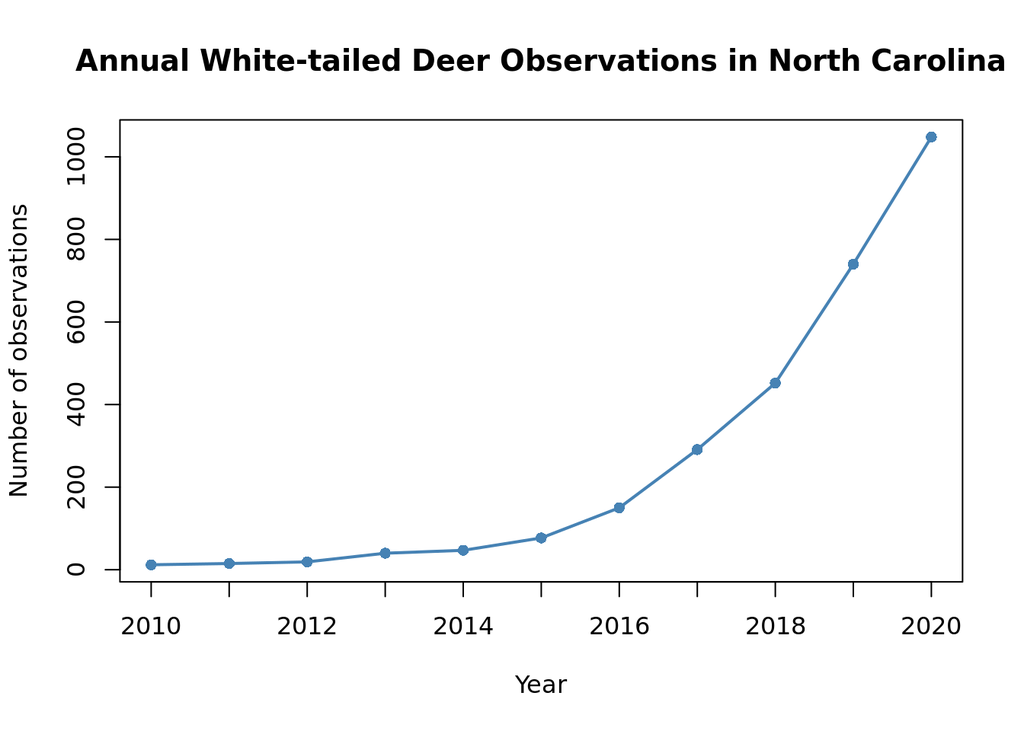

```r
# Figure 1: Annual white-tailed deer observations in NC

plot(
  annual_counts$Year,
  annual_counts$Observations,
  type = "o",
  pch = 16,
  col = "steelblue",
  lwd = 2,
  xlab = "Year",
  ylab = "Number of observations",
  main = "Annual White-tailed Deer Observations in North Carolina",
  xaxt = "n"
)

axis(
  1,
  at = 2010:2020,
  labels = 2010:2020
)
```

### Figure 1. Annual White-tailed Deer Observations in North Carolina (2010–2020)

Question: How did the number of recorded white-tailed deer observations change from 2010 to 2020? Observed pattern: The annual number of observations increased (12 records in 2010 to 1,048 in 2020). Units: Number of iNaturalist observation records per year. Limitation: The observed numbers do not equate to the actual number of deer populations. This trend may merely indicate an increase in people’s participation on the iNaturalist platform, rather than an actual growth in the deer population.

```r
# Load North Carolina county boundaries
nc_map <- st_read("data/processed/NC_map_joined.shp")
```

```r
# Convert deer coordinates into spatial points
deer_sf <- st_as_sf(
  df_deer_clean,
  coords = c("longitude", "latitude"),
  crs = 4326,
  remove = FALSE
)

# Match the coordinate system of the county map
deer_sf <- st_transform(deer_sf, st_crs(nc_map))

# Assign each deer observation to a county
deer_county <- st_join(
  deer_sf,
  nc_map[, c("NAME", "GEOID")],
  join = st_within,
  left = TRUE
)

# Preview the results
head(st_drop_geometry(deer_county)[, c("id", "NAME", "GEOID")])
```

```
## # A tibble: 6 × 3
##       id NAME      GEOID
##    <dbl> <chr>     <chr>
## 1  18471 Brunswick 37019
## 2  24092 Pender    37141
## 3  86366 Orange    37135
## 4 117764 Stokes    37169
## 5 246028 Robeson   37155
## 6 325785 Dare      37055
```

```r
# Count deer observations by county
county_counts <- as.data.frame(
  table(deer_county$NAME)
)

# Rename columns
names(county_counts) <- c("NAME", "deer_count")

# Convert counts to numeric
county_counts$deer_count <- as.integer(county_counts$deer_count)

# Preview
head(county_counts)
```

```
##        NAME deer_count
## 1  Alamance         13
## 2 Alexander          1
## 3 Alleghany         20
## 4     Anson         16
## 5      Ashe         14
## 6     Avery        125
```

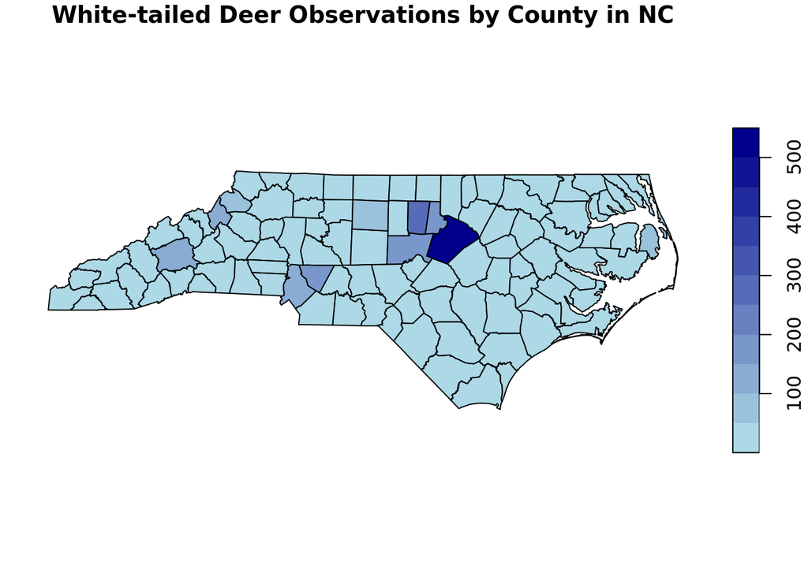

```r
# Join deer counts to county boundaries
nc_map$deer_count <- county_counts$deer_count[
  match(nc_map$NAME, county_counts$NAME)
]

# Counties with no observations should have a count of zero
nc_map$deer_count[is.na(nc_map$deer_count)] <- 0

# Figure 2: Deer observations by county
plot(
  nc_map["deer_count"],
  main = "White-tailed Deer Observations by County in NC",
  pal = colorRampPalette(c("lightblue", "darkblue")),
  key.pos = 4,
  axes = FALSE,
  reset = FALSE
)
```

### Figure 2. Spatial Distribution of White-tailed Deer Observations by County in North Carolina (2010–2020)

Question: How are white-tailed deer observations distributed across North Carolina counties? Observed pattern: Deer observations were unevenly distributed across counties. Units: Number of iNaturalist deer observation records per county. Limitation: Observation counts were not adjusted for county area or differences in observer. Additionally, 33 observations could not be assigned to a county and were excluded from this map. Therefore, higher observation counts do not necessarily indicate higher deer population density.

```r
# Summary table for all 100 counties
all_counties <- data.frame(
  County = nc_map$NAME,
  Observations = nc_map$deer_count
)

# Sort from highest to lowest
all_counties <- all_counties[
  order(-all_counties$Observations),
]

knitr::kable(
  all_counties,
  row.names = FALSE,
  caption = "Deer Observations by County (2010–2020)"
)
```

Deer Observations by County (2010–2020)

| County | Observations |
| --- | --- |
| Wake | 547 |
| Orange | 265 |
| Durham | 188 |
| Chatham | 174 |
| Cabarrus | 167 |
| Avery | 125 |
| Buncombe | 125 |
| Mecklenburg | 102 |
| Dare | 95 |
| Watauga | 65 |
| Guilford | 55 |
| Harnett | 45 |
| Catawba | 41 |
| Pitt | 36 |
| Madison | 33 |
| Transylvania | 32 |
| Brunswick | 31 |
| Haywood | 30 |
| Iredell | 30 |
| Henderson | 26 |
| Davidson | 22 |
| Union | 22 |
| Forsyth | 22 |
| Carteret | 21 |
| Caldwell | 21 |
| Swain | 20 |
| Alleghany | 20 |
| Hyde | 19 |
| Surry | 19 |
| Johnston | 19 |

[output cut: 70 more lines]

```r
# Top 10 counties by deer observations

county_top10 <- county_counts[
  order(county_counts$deer_count, decreasing = TRUE),
][1:10, ]

# Add ranking
county_top10 <- data.frame(
  Rank = 1:10,
  County = county_top10$NAME,
  Observations = county_top10$deer_count
)

# Display as a formatted table
knitr::kable(
  county_top10,
  caption = "Top 10 NC Counties by White-tailed Deer Observations (2010–2020)",
  row.names = FALSE
)
```

Top 10 NC Counties by White-tailed Deer Observations (2010–2020)

| Rank | County | Observations |
| --- | --- | --- |
| 1 | Wake | 547 |
| 2 | Orange | 265 |
| 3 | Durham | 188 |
| 4 | Chatham | 174 |
| 5 | Cabarrus | 167 |
| 6 | Avery | 125 |
| 7 | Buncombe | 125 |
| 8 | Mecklenburg | 102 |
| 9 | Dare | 95 |
| 10 | Watauga | 65 |

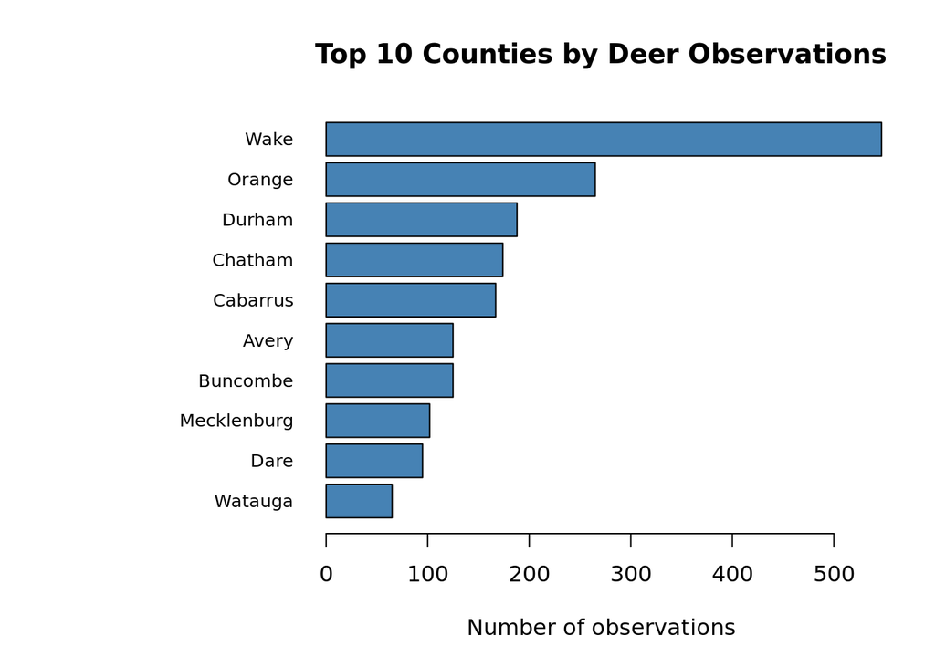

```r
# Horizontal bar chart for top 10 counties
par(mar = c(5, 12, 4, 2))

barplot(
  rev(county_top10$Observations),
  names.arg = rev(county_top10$County),
  horiz = TRUE,
  las = 1,
  col = "steelblue",
  cex.names = 0.8,
  xlab = "Number of observations",
  main = "Top 10 Counties by Deer Observations"
)
```

### Three main findings Temporal increase: Deer observation records increased substantially from 2010 to 2020, especially after 2016. Uneven spatial distribution: Observations were not evenly distributed across North Carolina counties. Concentration in a few counties: Wake (547), Orange (265), and Durham (188) together accounted for approximately 35% of county-assigned observations.